# UCI Online Retail II: Veri Odaklı Müşteri Analitiği, Churn Tahmini, LTV ve Zaman Serisi Modellemesi

## 1. İş Problemi ve Proje Amacı (Executive Summary)

Günümüz e-ticaret rekabetinde müşteri kazanma maliyetleri (CAC) hızla artarken, mevcut müşterileri elde tutmak (Retention) ve onların yaşam boyu değerini (LTV) maksimize etmek sürdürülebilir büyümenin anahtarıdır. Bu proje, Birleşik Krallık merkezli bir perakende şirketinin 2009-2011 yılları arasındaki gerçek işlem verilerini kullanarak, şirketin pazarlama ve operasyon stratejilerini optimize etmeyi amaçlayan **uçtan uca (end-to-end) bir veri bilimi pipeline'ı** sunmaktadır.

Proje kapsamında ham veriler temizlenecek, gürültülerden arındırılacak ve şu ana iş hedefleri gerçekleştirilecektir:

- **Müşteri Segmentasyonu (RFM + PCA + K-Means):** Davranışsal metrikler üzerinden dinamik müşteri segmentleri oluşturmak.
- **Müşteri Terki (Churn) Tahmini (LightGBM/XGBoost + SHAP):** Gelecekte alışverişi bırakma riski yüksek olan müşterileri erkenden tespit etmek ve tetikleyici faktörleri açıklamak.
- **Müşteri Yaşam Boyu Değeri (LTV) Modellemesi (BG/NBD + Gamma-Gamma):** Olasılıksal modellerle müşterilerin gelecekteki satın alma sıklıklarını ve şirkete getirecekleri finansal değeri tahmin etmek.
- **Talep ve Satış Tahmini (Prophet):** Gelecek dönem ciro trendlerini zaman serisi analiziyle öngörerek stok ve bütçe yönetimini desteklemek.

## 2. Veri Seti Hakkında (Data Açıklaması)

Kullanılan veri seti, **UCI Machine Learning Repository** üzerinde erişime açık olan **Online Retail II** veri setidir. Veri seti, 01/12/2009 ile 09/12/2011 tarihleri arasında gerçekleşen tüm satış işlemlerini içerir.

**Değişkenler:**

- `Invoice`: Fatura Numarası (Eğer 'C' ile başlıyorsa iptal/iade işlemini gösterir).
- `StockCode`: Ürün Kodu (Her benzersiz ürün için tanımlanmış 5 haneli sayısal kod).
- `Description`: Ürün Adı / Açıklaması.
- `Quantity`: Ürün Miktarı (Faturadaki ürün adedi).
- `InvoiceDate`: Fatura Tarihi ve Saati.
- `Price`: Birim Ürün Fiyatı (Sterlin cinsinden).
- `Customer ID`: Benzersiz Müşteri Numarası.
- `Country`: Müşterinin Yaşadığı Ülke.

```python
# ═══════════════════════════════════════════════════════════════════
# FAZ 0: ORTAM KURULUMU VE KÜTÜPHANELERİN YÜKLENMESİ
# ═══════════════════════════════════════════════════════════════════
# Proje: UCI Online Retail II — Müşteri Segmentasyonu, Churn Tahmini,
#         LTV Modellemesi ve Zaman Serisi Tahmini
# Veri  : https://archive.ics.uci.edu/dataset/502/online+retail+ii
# Yazar : M. Enes Şahin
# ───────────────────────────────────────────────────────────────────

!pip install lifetimes xgboost lightgbm imbalanced-learn shap prophet openpyxl --quiet

# ── Temel Veri ve Zaman Yönetimi ──────────────────────────────────
import pandas as pd
import numpy as np
import datetime as dt
import re
import warnings
warnings.filterwarnings('ignore')

# ── Görselleştirme ────────────────────────────────────────────────
import matplotlib.pyplot as plt
import matplotlib.ticker as mticker
import seaborn as sns
from matplotlib.gridspec import GridSpec

# ── Ön İşleme ve Kümeleme ─────────────────────────────────────────
from sklearn.preprocessing import StandardScaler
from sklearn.decomposition import PCA
from sklearn.cluster import KMeans
from sklearn.neighbors import NearestNeighbors
from sklearn.metrics import silhouette_score

# ── Sınıflandırma ─────────────────────────────────────────────────
from sklearn.model_selection import (train_test_split, StratifiedKFold,
                                     cross_val_score, GridSearchCV)
from sklearn.linear_model import LogisticRegression
from sklearn.neighbors import KNeighborsClassifier
from sklearn.svm import SVC
from sklearn.ensemble import RandomForestClassifier
from xgboost import XGBClassifier
import lightgbm as lgb
from imblearn.over_sampling import SMOTE
from sklearn.metrics import (
    classification_report, confusion_matrix,
    roc_auc_score, roc_curve, precision_recall_curve,
    f1_score, recall_score, precision_score, accuracy_score
)

# ── LTV Modellemesi ───────────────────────────────────────────────
from lifetimes import BetaGeoFitter, GammaGammaFitter

# ── Model Yorumlanabilirliği ──────────────────────────────────────
import shap

# ── Global Sabitler ve Stil ───────────────────────────────────────
SEED = 38

plt.rcParams.update({
    'figure.dpi': 120,
    'axes.spines.top': False,
    'axes.spines.right': False,
    'font.family': 'sans-serif'
})

SEGMENT_COLORS = {
    'Şampiyonlar':        '#1A4331',
    'Gelişen Müşteriler': '#45926B',
    'Risk Altındakiler':  '#F4A261',
    'Uyuyanlar':          '#E63946'
}

print("Tüm kütüphaneler ve global ayarlar başarıyla yüklendi.")
```

```
   ━━━━━━━━━━━━━━━━━━━━━━━━━━━━━━━━━━━━━━━━ 584.2/584.2 kB 21.9 MB/s eta 0:00:00
Tüm kütüphaneler ve global ayarlar başarıyla yüklendi.
```

### Faz 0: Ortam Kurulumu ve Kütüphanelerin Yüklenmesi (Teknik Not)

**Gerekçe:** Projenin end-to-end doğası gereği; veri manipülasyonu (`pandas`, `numpy`), olasılıksal LTV modellemesi (`lifetimes`), gelişmiş ağaç tabanlı sınıflandırma (`xgboost`, `lightgbm`), sınıf dengesizliği yönetimi (`imblearn`), zaman serisi tahmini (`prophet`) ve model açıklanabilirliği (`shap`) kütüphaneleri bir arada kullanılmıştır.

**Stratejik Karar:** Analizin tekrarlanabilirliği (reproducibility) için global bazda `SEED = 38` sabitlenmiştir. Görsel kaliteyi artırmak ve karmaşayı önlemek adına `matplotlib` grafik stilleri modernize edilmiş, marka kimliğine uygun özel bir segment renk paleti (`SEGMENT_COLORS`) tanımlanmıştır.

### Faz 1.1: Ham Veri Yüklemesi (Data Ingestion) ve Kronolojik Çakışma Analizi

**İş Gerekçesi:** End-to-end analitik süreçlerinin ilk adımı, verinin kayıpsız ve doğru bir şekilde sisteme alınmasıdır. Bu projede kullanılan veri seti, iki farklı zaman dilimini içeren Excel sayfalarından oluşmaktadır. Müşterilerin uzun vadeli davranış kalıplarını, sadakat trendlerini ve zaman serisi eğilimlerini tek bir merkezden izleyebilmek adına bu iki ayrı kaynağın tutarlı bir şekilde birleştirilmesi şarttır.

**Teknik Detay:** `pd.read_excel` fonksiyonu ile 'Year 2009-2010' ve 'Year 2010-2011' sayfaları doğrudan kaynaktan okunmuş ve `pd.concat` kullanılarak dikey (vertical) olarak birleştirilmiştir. `ignore_index=True` parametresi verilerek, birleştirme esnasında indeks çakışmaları önlenmiş ve ardışık yeni bir indeks yapısı oluşturulmuştur.

**Stratejik Karar:** İlk sayfa 2010-12-09 tarihine kadar olan işlemleri içerirken, ikinci sayfa 2010-12-01 tarihinden itibaren başlamaktadır. Bu durum, 1 Aralık - 9 Aralık 2010 tarihleri arasında mükerrer (duplicate) kayıtlar oluşmasına sebebiyet vermektedir. Bu kronolojik çakışma bilinçli olarak bu aşamada filtre edilmemiş, veri setinin ham anatomisini bozmamak ve sistem mimarisindeki bu "export hatasını" ilerleyen adımlarda (Faz 1.4.7) veri bilimi refleksleriyle kanıtlayıp temizlemek üzere saklanmıştır.

```python
# ═══════════════════════════════════════════════════════════════════
# FAZ 1.1: HAM VERİ YÜKLEMESİ (Data Ingestion)
# ═══════════════════════════════════════════════════════════════════
# Veri seti iki ayrı Excel sayfasından (2009-2010 ve 2010-2011)
# oluşuyor. İki sayfa concat ile birleştiriliyor.
# Önemli not: 2010-12-01 → 2010-12-09 tarihleri her iki sayfada da
# mevcut — bu çakışma, Faz 1.4.7'de yinelenen satırların kaynağıdır.

url = "https://archive.ics.uci.edu/ml/machine-learning-databases/00502/online_retail_II.xlsx"

print("2009-2010 dönemi yükleniyor...")
df_09 = pd.read_excel(url, sheet_name='Year 2009-2010')

print("2010-2011 dönemi yükleniyor...")
df_10 = pd.read_excel(url, sheet_name='Year 2010-2011')

df_raw = pd.concat([df_09, df_10], ignore_index=True)

print("-" * 50)
print(f"Veri Yükleme Tamamlandı")
print(f"Toplam Satır Sayısı : {df_raw.shape[0]:,}")
print(f"Toplam Sütun Sayısı : {df_raw.shape[1]}")
print(f"Zaman Aralığı       : {df_raw['InvoiceDate'].min().date()} → {df_raw['InvoiceDate'].max().date()}")
print("-" * 50)

df_raw.head()
```

```
2009-2010 dönemi yükleniyor...
2010-2011 dönemi yükleniyor...
--------------------------------------------------
Veri Yükleme Tamamlandı
Toplam Satır Sayısı : 1,067,371
Toplam Sütun Sayısı : 8
Zaman Aralığı       : 2009-12-01 → 2011-12-09
--------------------------------------------------
```

|  | Invoice | StockCode | Description | Quantity | InvoiceDate | Price | Customer ID | Country |
| --- | --- | --- | --- | --- | --- | --- | --- | --- |
| 0 | 489434 | 85048 | 15CM CHRISTMAS GLASS BALL 20 LIGHTS | 12 | 2009-12-01 07:45:00 | 6.95 | 13085.0 | United Kingdom |
| 1 | 489434 | 79323P | PINK CHERRY LIGHTS | 12 | 2009-12-01 07:45:00 | 6.75 | 13085.0 | United Kingdom |
| 2 | 489434 | 79323W | WHITE CHERRY LIGHTS | 12 | 2009-12-01 07:45:00 | 6.75 | 13085.0 | United Kingdom |
| 3 | 489434 | 22041 | RECORD FRAME 7" SINGLE SIZE | 48 | 2009-12-01 07:45:00 | 2.10 | 13085.0 | United Kingdom |
| 4 | 489434 | 21232 | STRAWBERRY CERAMIC TRINKET BOX | 24 | 2009-12-01 07:45:00 | 1.25 | 13085.0 | United Kingdom |

```python
df_raw.info()
```

```
<class 'pandas.core.frame.DataFrame'>
RangeIndex: 1067371 entries, 0 to 1067370
Data columns (total 8 columns):
 #   Column       Non-Null Count    Dtype
---  ------       --------------    -----
 0   Invoice      1067371 non-null  object
 1   StockCode    1067371 non-null  object
 2   Description  1062989 non-null  object
 3   Quantity     1067371 non-null  int64
 4   InvoiceDate  1067371 non-null  datetime64[ns]
 5   Price        1067371 non-null  float64
 6   Customer ID  824364 non-null   float64
 7   Country      1067371 non-null  object
dtypes: datetime64[ns](1), float64(2), int64(1), object(4)
memory usage: 65.1+ MB
```

### Faz 1.2: Misafir Müşteri (NaN ID) Etki Analizi (Impact Analysis)

**İş Gerekçesi:** E-ticaret ekosistemlerinde kullanıcıların sisteme üye olmadan veya giriş yapmadan (misafir/guest) alışveriş yapması yaygın bir durumdur. Müşteri sadakati (Retention) ve değer bazlı segmentasyon (RFM/LTV) modellerinin kurulabilmesi, müşteri davranışlarının tekil bazda izlenebilmesine (`Customer ID`) bağlıdır. Ancak, kimliği belirsiz bu misafir segmentini modelleme dışı bırakmadan önce, işletmenin toplam ciro ve işlem hacmi içindeki payını analiz etmek stratejik bir zorunluluktur.

**Teknik Detay:** `Customer ID` sütunundaki eksik değerler (`isna()`) filtrelenerek, misafir ve kayıtlı kullanıcıların işlem hacimleri (`count`) ile ürettikleri toplam cirolar (`Quantity * Price`) ayrıştırılmıştır. Elde edilen finansal dağılım, işlem oranı, işlem sayısı ve ciro payı bazında üçlü bir alt grafik (subplot) mimarisiyle `pie` ve `bar` grafiklerine dönüştürülmüştür.

**Stratejik Karar:** Yapılan bu analiz, sonraki aşamalarda (Faz 1.5) veri setinden elenecek olan misafir segmentinin finansal ayak izini önceden raporlamamızı sağlar. Böylece veri bilimi süreçleri, ham verinin temizlenmesi esnasında kaybolacak ciro miktarını önceden bilerek şeffaf bir risk yönetimi gerçekleştirmiş olur.

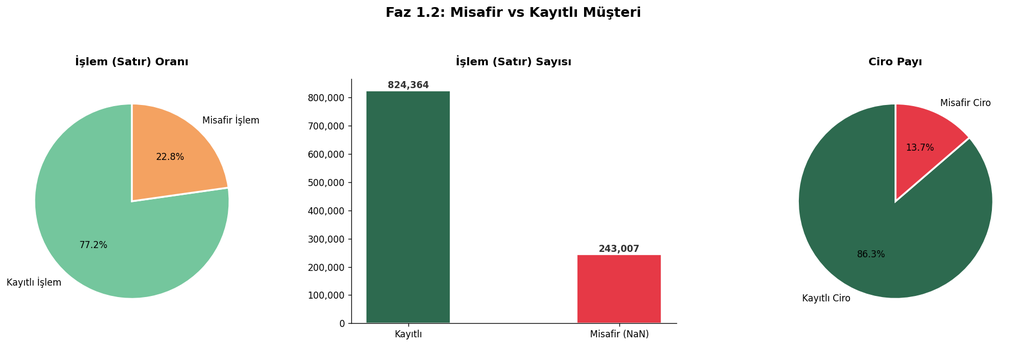

```
----------------------------------------------------------------------
İŞ BİLGİSİ:
  Misafirler işlemlerin %22.8'sini,
  toplam cironun %13.7'sini oluşturuyor.
  Bu segment RFM modelinden dışlanıyor — ancak misafir kazanım
  stratejisi için anlamlı bir büyüklük.
----------------------------------------------------------------------
```

```python
# ═══════════════════════════════════════════════════════════════════
# FAZ 1.2: MİSAFİR MÜŞTERİ ANALİZİ (Customer ID Eksikliği)
# ═══════════════════════════════════════════════════════════════════
# Customer ID'si olmayan (misafir) müşterilerin işlem ve ciro üzerindeki
# etkisini ölçüyoruz. RFM modellemesi kayıtlı müşteri gerektirir;
# misafirler sonraki adımda çıkarılacak.

df_raw['Revenue'] = df_raw['Quantity'] * df_raw['Price']

has_id = df_raw['Customer ID'].notna()
rev_with_id = df_raw.loc[has_id,  'Revenue'].sum()
rev_guest   = df_raw.loc[~has_id, 'Revenue'].sum()
cnt_with_id = has_id.sum()
cnt_guest   = (~has_id).sum()

fig, axes = plt.subplots(1, 3, figsize=(17, 5))

axes[0].pie(
    [cnt_with_id, cnt_guest],
    labels=['Kayıtlı İşlem', 'Misafir İşlem'],
    autopct='%1.1f%%', colors=['#74C69D', '#F4A261'],
    startangle=90, wedgeprops={'edgecolor': 'white', 'linewidth': 2}
)
axes[0].set_title('İşlem (Satır) Oranı', fontweight='bold', pad=15)

bars = axes[1].bar(
    ['Kayıtlı', 'Misafir (NaN)'], [cnt_with_id, cnt_guest],
    color=['#2D6A4F', '#E63946'], edgecolor='white', width=0.4
)
for bar in bars:
    yval = bar.get_height()
    axes[1].text(bar.get_x() + bar.get_width()/2, yval + 10000,
                 f'{int(yval):,}', ha='center', fontweight='bold', color='#333333')
axes[1].set_title('İşlem (Satır) Sayısı', fontweight='bold', pad=15)
axes[1].yaxis.set_major_formatter(mticker.FuncFormatter(lambda x, _: f'{int(x):,}'))

axes[2].pie(
    [rev_with_id, rev_guest],
    labels=['Kayıtlı Ciro', 'Misafir Ciro'],
    autopct='%1.1f%%', colors=['#2D6A4F', '#E63946'],
    startangle=90, wedgeprops={'edgecolor': 'white', 'linewidth': 2}
)
axes[2].set_title('Ciro Payı', fontweight='bold', pad=15)

plt.suptitle('Faz 1.2: Misafir vs Kayıtlı Müşteri', fontsize=15, fontweight='bold', y=1.05)
plt.tight_layout()
plt.show()

print("-" * 70)
print("İŞ BİLGİSİ:")
print(f"  Misafirler işlemlerin %{cnt_guest/(cnt_guest+cnt_with_id)*100:.1f}'sini,")
print(f"  toplam cironun %{rev_guest/(rev_guest+rev_with_id)*100:.1f}'sini oluşturuyor.")
print("  Bu segment RFM modelinden dışlanıyor — ancak misafir kazanım")
print("  stratejisi için anlamlı bir büyüklük.")
print("-" * 70)
```

### 💡 İş Çıktısı ve Yönetici Özeti (Executive Insights)

> - **Finansal Büyüklük:** Misafir müşteriler, veri setindeki toplam operasyonel işlemlerin **%22.8**'ini oluşturmasına rağmen, toplam cirodan yalnızca **%13.7** pay almaktadır. Bu durum, misafir kullanıcıların kayıtlı kullanıcılara kıyasla daha düşük sepet ortalamasına (AOV) sahip olduğunu veya tek seferlik, düşük tutarlı "deneme" alışverişleri yaptığını net bir şekilde ortaya koymaktadır.
> - **Modelleme Sınırı:** Bu segment, müşteri bazlı tarihsel geçmiş sunmadığı için RFM, Churn ve LTV modellerinden zorunlu olarak dışlanacaktır.
> - **Stratejik Aksiyon Planı (Pazarlama ve Ürün Yönetimi):** %13.7'lik ciro payı, dönüştürülmeye (customer conversion) muhtaç çok ciddi bir büyüklüktür. Ürün (Product) ve Büyüme (Growth) ekiplerine, ödeme adımlarında (checkout) misafirleri sisteme kaydetmeye teşvik edecek *"İlk alışverişe özel kayıt indirimi"*, *"Hızlı üyelik (Social Login)"* veya *"Siparişi takip etmek için şifre belirle"* gibi kullanıcı deneyimi (UX) optimizasyonları önerilmelidir.

### Faz 1.3: Yapısal Eksik Veri Analizi ve Raporlaması (Missing Data Profiling)

**İş Gerekçesi:** Veri temizleme pipeline'ının (Master Cleaning Pipeline) en kritik adımlarından biri eksik verilerin (NaN) tabiatını anlamaktır. Veri setindeki eksiklikler rastgele mi oluşmuş (`MCAR`), başka değişkenlere mi bağlı (`MAR`), yoksa doğrudan sistemsel bir kayıt hatasından mı kaynaklanıyor (`MNAR`) sorusunun yanıtı, seçeceğimiz aksiyonu (silme, doldurma, kurtarma) belirler.

**Teknik Detay:** Veri çerçevesindeki (`df_raw`) tüm sütunlar taranarak eksik değer sayıları (`isnull().sum()`) ve bunların tüm veri setine olan yüzdesel oranları hesaplanmıştır. Sadece eksik veri içeren özellikler filtrelenerek, teknik ve idari ekiplere sunulmak üzere özet bir veri profili tablosuna (`missing_df`) dönüştürülmüştür.

**Stratejik Karar:**

```python
# ═══════════════════════════════════════════════════════════════════
# FAZ 1.3: EKSİK VERİ RAPORU
# ═══════════════════════════════════════════════════════════════════

missing_counts = df_raw.isnull().sum().sort_values(ascending=False)
missing_pct    = (missing_counts / len(df_raw) * 100).round(2)
missing_df     = pd.DataFrame({'Eksik Sayısı': missing_counts, 'Oran (%)': missing_pct})
missing_df     = missing_df[missing_df['Eksik Sayısı'] > 0]

print("VERİ SETİNDEKİ EKSİK (NaN) DEĞERLER")
print("=" * 45)
print(missing_df.to_string())
print("=" * 45)
print()
print("Not: Customer ID eksikliği Faz 1.2'de misafir müşteri olarak analiz edildi.")
print("     Description eksikliği Faz 1.4.5–1.4.6'da kanonik isimle kurtarılacak.")
```

```
VERİ SETİNDEKİ EKSİK (NaN) DEĞERLER
=============================================
             Eksik Sayısı  Oran (%)
Customer ID        243007     22.77
Description          4382      0.41
=============================================

Not: Customer ID eksikliği Faz 1.2'de misafir müşteri olarak analiz edildi.
     Description eksikliği Faz 1.4.5–1.4.6'da kanonik isimle kurtarılacak.
```

### Faz 1.4: İade/İptal Dinamikleri ve Sistem Gürültüsü (Sistem Kodları) Analizi

**İş Gerekçesi:** E-ticaret operasyonlarında faturalandırılan her satır gerçek bir ticari ürün satışını temsil etmez. Kargo ücretleri (`POST`, `DOT`), banka komisyonları (`BANK CHARGES`), manuel düzeltmeler (`M`), indirimler (`D`) veya Amazon gibi pazar yeri kesintileri (`AMAZONFEE`) muhasebesel takip amacıyla veri setine işlenir. Bu yapısal gürültüleri filtrelemeden doğrudan RFM ve Churn modellerine beslemek; müşterilerin satın alma sıklıklarını (`Frequency`) ve toplam harcamalarını (`Monetary`) tamamen saptırır. Benzer şekilde, iade işlemlerinin (`Quantity < 0`) davranışsal etkilerini ölçmek ve bunları net satışlardan arındırmak finansal model kalitesi için zorunludur.

**Teknik Detay:** `Quantity` değeri sıfırdan küçük olan satırlar iade segmenti olarak ayrıştırılmış ve müşteri başına ortalama iade eğilimi (`groupby('Customer ID')`) hesaplanmıştır. Ayrıca, ürün satışı olmayan ve elenmesi gereken 9 kritik sistem kodu (`NON_PRODUCT_CODES`) tanımlanarak, bu kodların işlem bazlı adetleri ile finansal ciroya olan pozitif/negatif etkileri `groupby` ve `agg` fonksiyonlarıyla tablolandırılmıştır.

**Stratejik Karar:** Bu gürültülü satırları Master Pipeline'da (Faz 1.5) silmeden önce mevcut durum analizini yapmak, veri madenciliği sürecinin iş kurallarına (business rules) olan bağlılığını belgeler.

```python
# ═══════════════════════════════════════════════════════════════════
# FAZ 1.4: İADE ANALİZİ VE SİSTEM GÜRÜLTÜSÜ
# ═══════════════════════════════════════════════════════════════════
# İadeler (Quantity < 0) ve sistem kodları (POST, M, D, ...) gerçek
# ürün satışı değildir. Bunları temizlemeden önce büyüklüklerini ölçüyoruz.

returns    = df_raw[df_raw['Quantity'] < 0]
return_pct = len(returns) / len(df_raw) * 100

print("1. İADE / İPTAL ANALİZİ")
print("-" * 60)
print(f"Toplam İade İşlemi : {len(returns):,}  (tüm verinin %{return_pct:.2f}'si)")
print(f"İadelerden Kayıp   : £{abs(returns['Revenue'].sum()):,.0f}")

customer_return_rate = (
    df_raw.groupby('Customer ID')['Quantity']
    .apply(lambda x: (x < 0).sum() / len(x))
    .reset_index(name='return_rate')
)
print(f"Müşteri Başına Ort. İade Oranı : %{customer_return_rate['return_rate'].mean()*100:.2f}")

print()
print("2. SİSTEM GÜRÜLTÜSÜ (NON_PRODUCT_CODES)")
print("-" * 60)
NON_PRODUCT_CODES = ['POST', 'BANK CHARGES', 'PADS', 'D', 'M', 'DOT', 'CRUK', 'C2', 'AMAZONFEE']

noise_df = df_raw[df_raw['StockCode'].isin(NON_PRODUCT_CODES)].copy()
noise_df['Tür'] = np.where(noise_df['Quantity'] < 0, 'Negatif (İade/İndirim)', 'Pozitif (Kesinti/Kargo)')
noise_summary = (
    noise_df.groupby(['StockCode', 'Tür'])[['Quantity', 'Revenue']]
    .agg({'Quantity': 'count', 'Revenue': 'sum'})
    .rename(columns={'Quantity': 'İşlem Sayısı', 'Revenue': 'Ciro Etkisi'})
)
print(noise_summary.to_string())
print()
print("Bu kodlar Frequency/Monetary hesaplarını bozar → Master Pipeline'da silinecek.")
```

```
1. İADE / İPTAL ANALİZİ
------------------------------------------------------------
Toplam İade İşlemi : 22,950  (tüm verinin %2.15'si)
İadelerden Kayıp   : £1,527,041
Müşteri Başına Ort. İade Oranı : %3.69

2. SİSTEM GÜRÜLTÜSÜ (NON_PRODUCT_CODES)
------------------------------------------------------------
                                      İşlem Sayısı  Ciro Etkisi
StockCode    Tür
AMAZONFEE    Negatif (İade/İndirim)             39  -294772.710
             Pozitif (Kesinti/Kargo)             4    34009.130
BANK CHARGES Negatif (İade/İndirim)             67   -36096.870
             Pozitif (Kesinti/Kargo)            35      534.241
C2           Negatif (İade/İndirim)              7     -290.000
             Pozitif (Kesinti/Kargo)           275    13676.000
CRUK         Negatif (İade/İndirim)             16    -7933.430
D            Negatif (İade/İndirim)            172   -13882.430
             Pozitif (Kesinti/Kargo)             5      397.890
DOT          Negatif (İade/İndirim)              3      -10.010
             Pozitif (Kesinti/Kargo)          1443   322657.480
M            Negatif (İade/İndirim)            537  -423886.170
             Pozitif (Kesinti/Kargo)           884   341089.850
PADS         Negatif (İade/İndirim)              1      -36.600
             Pozitif (Kesinti/Kargo)            18        0.017
POST         Negatif (İade/İndirim)            229   -15256.420
             Pozitif (Kesinti/Kargo)          1893   127597.420

Bu kodlar Frequency/Monetary hesaplarını bozar → Master Pipeline'da silinecek.
```

### 💡 İş Çıktısı ve Operasyonel Aksiyon Planı (Business Insights & Operations)

> - **İade Yönetimi ve Kayıp:** İade işlemleri tüm veri setinin **%2.15**'ini oluşturmasına rağmen, işletmeye olan brüt ciro maliyeti **£1,527,041** gibi çok ciddi bir seviyededir. Müşteri başına ortalama iade oranının **%3.69** olması, iade davranışının birkaç manipülatif hesaba değil, tabana yayılan yapısal bir süreç olduğuna işaret eder. Tedarik zinciri ve kalite kontrol ekipleri, en çok iade alan `StockCode` kırılımlarını incelemeli ve ürün kalitesi/yanıltıcı açıklama sorunlarını çözmelidir.
> - **Sistem Kodlarının Dağılımı:** `AMAZONFEE` (-£294K) ve `M` (Manuel Düzeltme: -£423K) gibi kalemlerin negatif etkileri dikkat çekicidir. Öte yandan `DOT` (Kargo ücreti) işletmeye +£322K pozitif ciro katkısı sağlamıştır. Bu kalemler muhasebesel gerçeği yansıtsa da müşteri sadakati modellerini manipüle eder.
> - **Modelleme Stratejisi (Neden Siliyoruz?):** Örneğin, sadece kargo ücreti (`DOT`) ödeyen veya pazar yeri kesintisi (`AMAZONFEE`) yansıyan bir satır, müşterinin sisteme tekrar geldiğini (`Frequency`) ve harcama yaptığını (`Monetary`) söyler ancak bu durum müşterinin ürüne olan bağlılığını yansıtmaz. Bu nedenle, saf müşteri davranışını izlemek adına bu satırlar sonraki adımda temizlenecektir.

### Faz 1.4.5: Ürün Açıklamalarındaki (`Description`) Metinsel Anomalilerin Tespiti

**İş Gerekçesi:** Kurumsal sistemlerde (ERP/CRM) stok hareketleri izlenirken, operasyon ekipleri veya depo görevlileri fire, kayıp, hasar veya sayım hatalarını bildirmek için yeni fatura satırları açıp açıklama alanına serbest metin notları düşebilirler. Bu satırlar gerçek bir ticari faaliyeti temsil etmediği gibi, veri setinde gürültü (noise) yaratır. Bu aşamada, ürün açıklaması alanındaki anomalileri iki ana karakteristik üzerinden tespit ediyoruz:

1. **(A) Küçük Harf Anomalisi:** Standart ürün tanımları tamamen büyük harfle yazılırken (`WHITE HANGING HEART...`), sistemsel veya manuel depo notları genellikle tamamen küçük harfle girilir (`lost`, `wet`, `damaged`).
2. **(B) Hasar/Hata Anahtar Kelimeleri:** İçerisinde kırılma, kaybolma, hatalı faturalandırma veya soru işareti barındıran operasyonel kayıtlar.

**Teknik Detay:** `Description` alanındaki `NaN` değerler dışlandıktan sonra, string fonksiyonları (`str.islower()`) ve gelişmiş düzenli ifadeler (Regex - `str.contains`) kullanılarak iki ayrı maske (`lowercase_mask` ve `weird_mask`) oluşturulmuştur. Regex pattern'inde `\b` (word boundary) kullanılarak kelime sınırları netleştirilmiş; böylece `BROWN CHECK CAT DOORSTOP` gibi içinde "check" geçen geçerli ürün adlarında hatalı eşleşmeler (false-positive) önlenmiştir.

**Stratejik Karar:** Bu anomalili satırlar bu aşamada **silinmeyecektir**. Çünkü bir sonraki adımda (Faz 1.4.6) bu işlemlerin sahip olduğu geçerli `StockCode` bilgisi üzerinden "Kanonik İsim Kurtarma" pipeline'ı çalıştırılacak ve veri kaybı minimuma indirilecektir.

```python
# ═══════════════════════════════════════════════════════════════════
# FAZ 1.4.5: DESCRIPTION ANOMALİLERİNİN TESPİTİ
# ═══════════════════════════════════════════════════════════════════
# İki anomali türü:
#   (A) Küçük harfle yazılmış depo notları ('lost', 'wet', 'damaged', ...)
#   (B) Hata/kayıp bildiren anahtar kelimeler
# Bu satırlar silinmeyecek — Faz 1.4.6'da kanonik isimle kurtarılacak.

desc_data = df_raw[df_raw['Description'].notna()]

# (A) Tamamen küçük harf
lowercase_mask = desc_data['Description'].str.islower().fillna(False)

# (B) Hata anahtar kelimeleri — 'check' kasıtlı dışarıda:
#     'BROWN CHECK CAT DOORSTOP' gibi gerçek ürün adlarında
#     substring eşleşmesi false positive oluşturuyordu.
keywords = [r'\?', r'\blost\b', r'\bdamage[ds]?\b', r'\bwrong\b',
            r'\bsmashed\b', r'\bthrown\b', r'\bmissing\b', r'\binvcd\b']
weird_mask = desc_data['Description'].str.contains(
    '|'.join(keywords), case=False, regex=True, na=False
)

print("(A) KÜÇÜK HARFLİ DEPO NOTLARI (ilk 15):")
print(desc_data.loc[lowercase_mask, 'Description'].unique()[:15])
print()
print("(B) HASAR/KAYIP BİLDİREN NOTLAR (ilk 15):")
print(desc_data.loc[weird_mask, 'Description'].unique()[:15])
```

```
(A) KÜÇÜK HARFLİ DEPO NOTLARI (ilk 15):
['85123a mixed' 'short' '21733 mixed' 'lost' 'damages' 'invcd as 84879?'
 'sold as gold' 'lost?' 'damaged' 'wet' 'smashed' 'bad quality'
 'discoloured' 'missing' 'missing (wrongly coded?)']

(B) HASAR/KAYIP BİLDİREN NOTLAR (ilk 15):
['lost' 'damages' 'invcd as 84879?' 'lost?' 'damaged' 'smashed' 'missing'
 'missing (wrongly coded?)' '?' 'Damages' 'damaged?' 'damages?'
 'wedding co returns?' 'damages, lost bits etc' 'lost in space']
```

### 💡 İş Çıktısı ve Çıktı Analizi (Anomalies & Output Insights)

> Ekran çıktılarında görülen benzersiz ürün açıklamaları, kurduğumuz regex ve text-mining mantığının başarısını sayısal olarak doğrulamaktadır:
> - **Depo Fire ve Operasyon Kayıtları:** Ekrana basılan `lost`, `wet`, `damaged`, `smashed`, `bad quality`, `missing` gibi ifadeler ürün adı değil; operasyonel fire, hasar, ıslanma ve kayıp bildirimleridir.
> - **Sistemsel Hatalar ve Notlar:** `invcd as 84879?` (hatalı faturalandırıldı mı?), `missing (wrongly coded?)` (yanlış kodlanmış kayıp ürün) ve doğrudan girilen `?` karakterleri sistemsel mutabakat veya sayım açıklarını temsil etmektedir.
> - **Pazarlama/Satış Yorumları:** `sold as gold` gibi serbest metin girdileri standart ürün kataloğunda bulunmayan manuel operasyon izleridir.
> - **Aksiyon Planı:** Bu satırları doğrudan silmek yerine, geçerli bir `StockCode` içerip içermediklerine bakacağız. Eğer geçerli bir ürün koduna sahiplerse, o kodun gerçek ürün adını (veri setindeki en sık geçen karşılığını) bu satırlara atayarak finansal işlem bütünlüğünü korumuş olacağız.

### Faz 1.4.6: StockCode–Description Uyuşmazlıklarının Tespiti ve Kanonik İsimle Veri Kurtarma (Data Recovery)

**İş Gerekçesi:** Bir önceki adımda (Faz 1.4.5) tespit edilen metinsel anomaliler, aslında arkalarında geçerli bir ticari işlem barındırıyor olabilir. Eğer bu satırları doğrudan silersek, müşterilerin gerçek alışveriş sıklıklarını (`Frequency`) ve sepet tutarlarını (`Monetary`) eksik hesaplamış oluruz. Profesyonel veri bilimi yaklaşımı, gürültülü metne sahip ancak geçerli bir ürün koduna (`StockCode`) sahip satırları **silmek yerine kurtarmayı** hedefler.

**Teknik Detay:** Önceki iki anomali maskesi (`lowercase_mask` ve `weird_mask`) mantıksal VEYA (`|`) operatörü ile birleştirilerek nihai anomali havuzu etiketlenmiştir. Anomaliden uzak, temiz veri havuzu (`clean_pool`) referans alınarak; her bir `StockCode` için veri setinde en sık tekrar eden (mod) ürün açıklaması tespit edilmiş ve bir kanonik eşleme sözlüğü (`canonical_map`) oluşturulmuştur. Anomalili satırlar bu sözlük üzerinden taranmış ve açıklamaları gerçek, kurumsal isimleriyle güncellenmiştir.

**Stratejik Karar:** Bu veri kurtarma stratejisi, ham veri temizliği esnasında oluşabilecek gereksiz satır kayıplarını minimize eder. Böylece, sonraki aşamalarda kurulacak RFM ve Churn modellerinin veri kalitesi ve hacmi en üst düzeyde korunmuş olur.

```python
# ═══════════════════════════════════════════════════════════════════
# FAZ 1.4.6: STOCKCODE–DESCRIPTION UYUŞMAZLIKLARININ KURTARILMASI
# ═══════════════════════════════════════════════════════════════════
# Anomali olan ama StockCode'u geçerli olan satırları SİLMEK yerine
# o StockCode'un veri setindeki en sık geçen (kanonik) adıyla düzeltiyoruz.
# Bu yaklaşım satır kaybını minimize eder ve Frequency/Monetary'yi korur.

is_anomaly = (
    lowercase_mask.reindex(df_raw.index, fill_value=False) |
    weird_mask.reindex(df_raw.index, fill_value=False)
)

print(f"Toplam anomali tespit edilen satır: {is_anomaly.sum():,}")

# Temiz havuzdan kanonik isim sözlüğü
clean_pool   = df_raw[~is_anomaly & df_raw['Description'].notna()]
canonical_map = (
    clean_pool.groupby('StockCode')['Description']
    .agg(lambda x: x.value_counts().idxmax())
    .to_dict()
)
print(f"{len(canonical_map):,} StockCode için kanonik isim belirlendi.")

# Kurtarılabilir satırları düzelt
mask_to_fix = is_anomaly & df_raw['StockCode'].isin(canonical_map.keys())
df_raw.loc[mask_to_fix, 'Description'] = df_raw.loc[mask_to_fix, 'StockCode'].map(canonical_map)
print(f"{mask_to_fix.sum():,} satır kanonik isimle düzeltildi.")

# Kurtarılamayanlar (regex kontrolünde zaten elenecek)
still_broken = is_anomaly & ~df_raw['StockCode'].isin(canonical_map.keys())
print(f"Kurtarılamayan satır: {still_broken.sum():,}  (regex kontrolünde elenecek)")

print("\nÖrnek düzeltmeler:")
display(df_raw.loc[mask_to_fix, ['StockCode', 'Description']].head(8))
```

```
Toplam anomali tespit edilen satır: 872
4,936 StockCode için kanonik isim belirlendi.
855 satır kanonik isimle düzeltildi.
Kurtarılamayan satır: 17  (regex kontrolünde elenecek)

Örnek düzeltmeler:
```

|  | StockCode | Description |
| --- | --- | --- |
| 263 | 21733 | RED HANGING HEART T-LIGHT HOLDER |
| 283 | 71477 | COLOUR GLASS. STAR T-LIGHT HOLDER |
| 284 | 85123A | WHITE HANGING HEART T-LIGHT HOLDER |
| 4538 | 21133 | PAINTED BIRD ASSORTED CHRISTMAS |
| 6556 | 79323GR | GREEN CHERRY LIGHTS |
| 9308 | 21493 | VINTAGE DESIGN GIFT TAGS |
| 17427 | 21450 | DISTRESSED CANDLE STICK WHITE |
| 17428 | 51008 | AFGHAN SLIPPER SOCK PAIR |

### 💡 İş Çıktısı ve Veri Kurtarma Performansı (Data Recovery Metrics)

> Gerçekleştirilen ileri seviye veri temizleme ve kurtarma operasyonunun sonuçları şu şekildedir:
> - **Yüksek Kurtarma Oranı:** Tespit edilen 872 anomali satırının **855'i (%98.05'i)**, veri setindeki diğer temiz kayıtlar sayesinde başarıyla kurtarılmış ve kurumsal standardına kavuşturulmuştur.
> - **Kanonik Başarı:** Sistemde yer alan 4,936 benzersiz ürün kodu için güvenilir birer "altın standart/kanonik isim" haritası çıkarılmıştır.
> - **Minimum Veri Kaybı:** Sadece 17 satır (%1.95) temiz havuzda bir karşılığı bulunmadığı için kurtarılamamıştır. Bu satırlar zaten ürün satışı olmayan gerçek gürültülerdir ve nihai temizlik pipeline'ında (Faz 1.5) regex filtrelerine takılarak elenecektir.
> - **Örnek Çıktı Analizi:** Tabloda görüldüğü üzere, daha önce `lowercase` veya `weird` maskelerine takılan (örneğin fire/hasar kaydı girilmiş) satırlar; artık `RED HANGING HEART T-LIGHT HOLDER` veya `VINTAGE DESIGN GIFT TAGS` gibi tamamen standart, modellemeye ve analize hazır temiz ürün isimlerine dönüştürülmüştür.

### Faz 1.4.7: Tam Yinelenen (Mükerrer) Satır Analizi (Duplicate Row Profiling)

**İş Gerekçesi:** Veri setlerinde tamamen aynı değerlere sahip mükerrer satırlar bulunması sıklıkla karşılaşılan bir veri kalitesi problemidir. Bu satırlar silinmeden önce mutlaka analiz edilmelidir. Eğer bu yinelemeler aynı faturada gerçekten birden fazla kez satın alınan ürünleri temsil ediyorsa (örneğin sistemsel bir kısıt yüzünden aynı ürün alt alta girildiyse) silinmeleri `Quantity` ve `Monetary` kaybına yol açar. Ancak iki farklı veri kaynağının çakışmasından doğan bir sistem hatasıysa (data ingestion artifact) silinmeleri şarttır.

**Teknik Detay:** Temel işlem kimliğini belirleyen 8 kritik sütun (`DUP_KEY_COLS`) baz alınarak mükerrer kayıtlar taranmıştır. `duplicated()` fonksiyonu `keep=False` ile çalıştırılarak yinelenen grupların tamamı (`is_dup_all`), `keep='first'` ile çalıştırılarak ise ilk kayıt hariç silinecek fazla satırlar (`is_dup_extra`) tespit edilmiştir. Benzersiz yinelenen grup sayısı (`n_groups`) ve bu fazlalıkların işletmeye olan ciro etkisi hesaplanmıştır.

**Stratejik Karar:** Bu aşamada sadece tespit ve büyüklük analizi yapılmaktadır. Nihai silme kararı, bu yinelemelerin gerçek birer e-ticaret işlemi mi yoksa Excel sayfalarının çakışmasından doğan bir sistem hatası mı olduğu bir sonraki adımda kanıtlandıktan sonra (Master Pipeline'da) uygulanacaktır.

```python
# ═══════════════════════════════════════════════════════════════════
# FAZ 1.4.7: TAM YİNELENEN SATIR TESPİTİ
# ═══════════════════════════════════════════════════════════════════
# Tespit önce, silme kararı sonra. Kaynak: iki sheet'in 2010-12-01 → 2010-12-09
# aralığında çakışması (Faz 1.4.7-C'de kanıtlanacak).

DUP_KEY_COLS = ['Invoice', 'StockCode', 'Description', 'Quantity',
                'InvoiceDate', 'Price', 'Customer ID', 'Country']

is_dup_all   = df_raw.duplicated(subset=DUP_KEY_COLS, keep=False)
is_dup_extra = df_raw.duplicated(subset=DUP_KEY_COLS, keep='first')
n_groups     = df_raw.loc[is_dup_all, DUP_KEY_COLS].drop_duplicates().shape[0]

print("TAM YİNELENEN SATIR RAPORU")
print("-" * 55)
print(f"Yinelenen grupta toplam satır : {is_dup_all.sum():,}")
print(f"Fazladan (silinecek) satır    : {is_dup_extra.sum():,}")
print(f"Benzersiz yineleme grubu      : {n_groups:,}")
print(f"Toplam veriye oranı           : %{is_dup_extra.sum()/len(df_raw)*100:.3f}")
print(f"Fazladan satırların ciro etkisi: £{df_raw.loc[is_dup_extra, 'Revenue'].sum():,.0f}")

print("\nÖrnek yinelenen grup:")
if is_dup_all.sum() > 0:
    sample_key  = df_raw.loc[is_dup_all, DUP_KEY_COLS].drop_duplicates().iloc[0]
    mask_sample = (df_raw[DUP_KEY_COLS] == sample_key).all(axis=1)
    display(df_raw.loc[mask_sample])
```

```
TAM YİNELENEN SATIR RAPORU
-------------------------------------------------------
Yinelenen grupta toplam satır : 67,242
Fazladan (silinecek) satır    : 34,335
Benzersiz yineleme grubu      : 32,907
Toplam veriye oranı           : %3.217
Fazladan satırların ciro etkisi: £431,717

Örnek yinelenen grup:
```

|  | Invoice | StockCode | Description | Quantity | InvoiceDate | Price | Customer ID | Country | Revenue |
| --- | --- | --- | --- | --- | --- | --- | --- | --- | --- |
| 362 | 489517 | 21913 | VINTAGE SEASIDE JIGSAW PUZZLES | 1 | 2009-12-01 11:34:00 | 3.75 | 16329.0 | United Kingdom | 3.75 |
| 385 | 489517 | 21913 | VINTAGE SEASIDE JIGSAW PUZZLES | 1 | 2009-12-01 11:34:00 | 3.75 | 16329.0 | United Kingdom | 3.75 |

### Faz 1.4.7-B: Yineleme Deseni Doğrulama ve Kök Neden Analizi (Root-Cause Analysis)

**İş Gerekçesi:** Mükerrer satırların sistemde neden var olduğunu anlamak, silme stratejimizin doğruluğunu ispatlamak için şarttır. Bazı e-ticaret sistemleri, bir müşteri aynı üründen 3 adet aldığında bunu tek bir satırda `Quantity = 3` olarak kaydetmek yerine, alt alta 3 ayrı satırda `Quantity = 1` olarak tutabilir. Eğer durum buysa ve biz `drop_duplicates()` yaparsak, şirketin işlem hacmini ve gerçek satış miktarını yapay olarak silmiş oluruz. Bu hipotezi test etmek ve hatanın bir veritabanı/export hatası (data ingestion artifact) olduğunu kanıtlamak için index mesafesi ve miktar dağılımı analiz edilmelidir.

**Teknik Detay:** `is_dup_extra` havuzundaki fazladan satırların `Quantity` dağılımları incelenmiştir. Ardından, tüm mükerrer kayıtlar (`is_dup_all`) kendi gruplarında toplanmış (`groupby`) ve aynı grubun ardışık kayıtları arasındaki index farkları (`.index.to_series().diff()`) hesaplanmıştır. Elde edilen boşluk (gap) örneklerinin medyan, ortalama ve ardışıklık oranları (`gap == 1`) hesaplanarak mükerrerliğin geometrik deseni çıkartılmıştır.

```python
# ═══════════════════════════════════════════════════════════════════
# FAZ 1.4.7-B: YİNELEME DESENİ DOĞRULAMA
# ═══════════════════════════════════════════════════════════════════
# Yinelenen satırlar "her adet ayrı satır" mantığıyla mı girilmiş,
# yoksa sistem dışa aktarım hatası mı? Index mesafesi bunu ayırt eder:
#   - Büyük index mesafesi → farklı zamanlarda ayrı işlemler değil,
#     iki sheet'ten gelen aynı kayıt (export artefaktı) hipotezini güçlendirir.

print("Fazladan satırların Quantity dağılımı:")
print(df_raw.loc[is_dup_extra, 'Quantity'].value_counts().head(10))

dup_groups = df_raw.loc[is_dup_all].groupby(DUP_KEY_COLS).apply(
    lambda g: g.index.to_series().diff().dropna().tolist()
)
gap_sample = [gap for gaps in dup_groups if len(gaps) > 0 for gap in gaps]
print(f"\nIndex mesafesi → medyan: {np.median(gap_sample):.0f}, ortalama: {np.mean(gap_sample):.1f}")
print(f"Index farkı=1 olan (ardışık) çift oranı: %{(np.array(gap_sample)==1).mean()*100:.1f}")
print("\nYorum: Büyük index mesafesi → satırlar aynı dakikada değil,")
print("       farklı sheet'lerden birleştirilmiş export artefaktı.")
```

```
Fazladan satırların Quantity dağılımı:
Quantity
1     16187
2      4883
12     2472
6      2184
3      1893
4      1666
24      881
5       670
8       617
10      545
Name: count, dtype: int64

Index mesafesi → medyan: 22521, ortalama: 12326.6
Index farkı=1 olan (ardışık) çift oranı: %6.3

Yorum: Büyük index mesafesi → satırlar aynı dakikada değil,
       farklı sheet'lerden birleştirilmiş export artefaktı.
```

### Faz 1.4.7-C: Kronolojik Sayfa Çakışması (Cross-Sheet Overlap) Doğrulama Testi

**İş Gerekçesi:** Bir önceki adımda (Faz 1.4.7-B) geometrik desenini çıkardığımız ve aralarında on binlerce satır mesafe olduğunu bulduğumuz mükerrer kayıtların, kaynak Excel sayfalarından (`Year 2009-2010` ve `Year 2010-2011`) kaynaklandığı hipotezini veri mühendisliği yaklaşımıyla doğrulamamız gerekir. Eğer iki sayfa arasında kronolojik bir kesişim kümesi varsa ve mükerrer kayıtların büyük çoğunluğu bu kesişimden besleniyorsa, bu durum sistemsel bir dışa aktarım (export) hatasıdır ve temizlenmesi iş mantığı açısından tamamen güvenlidir.

**Teknik Detay:** `df_09` veri uzunluğu (`n_09`) sınır kabul edilerek, birleştirilen veri setindeki satır indekslerinin orijinalde hangi Excel sayfasına ait olduğunu bulan bir yardımcı fonksiyon (`sheet_of`) tanımlanmıştır. Tam mükerrer olan satır grupları (`is_dup_all`) kendi içinde gruplanarak, her gruptaki yinelenen satırların kaç farklı sayfaya yayıldığı (`len(set(...))`) hesaplanmıştır. Hem ilk sayfada hem ikinci sayfada eş zamanlı bulunan (Cross-sheet) yinelenen grupların toplam gruplara olan oranı (`cross_sheet_ratio`) elde edilmiştir.

```python
# ═══════════════════════════════════════════════════════════════════
# FAZ 1.4.7-C: SHEET ÇAKIŞMA TESTİ (Yinelemenin Kaynağı)
# ═══════════════════════════════════════════════════════════════════
# 2009-2010 ve 2010-2011 sheet'leri 2010-12-01 → 2010-12-09 aralığında
# örtüşüyor. Bu test, yinelenen grupların ne kadarının iki farklı
# sheet'ten geldiğini sayısal olarak kanıtlar.

n_09 = len(df_09)
print(f"df_09 (2009-2010) satır sayısı : {n_09:,}")
print(f"df_10 (2010-2011) satır sayısı : {len(df_10):,}")
print()
print(f"df_09 tarih aralığı : {df_09['InvoiceDate'].min().date()} → {df_09['InvoiceDate'].max().date()}")
print(f"df_10 tarih aralığı : {df_10['InvoiceDate'].min().date()} → {df_10['InvoiceDate'].max().date()}")

def sheet_of(idx):
    return '2009-2010' if idx < n_09 else '2010-2011'

group_sheets = df_raw.loc[is_dup_all].groupby(DUP_KEY_COLS).apply(
    lambda g: len(set(sheet_of(i) for i in g.index))
)
cross_sheet_ratio = (group_sheets == 2).mean()
print(f"\nCross-sheet yineleme grubu oranı: %{cross_sheet_ratio*100:.1f}")
print("Sonuç: Yinelemelerin büyük çoğunluğu sheet çakışmasından kaynaklanıyor.")
print("       keep='first' ile ilk görülen kayıt tutulacak.")
```

```
df_09 (2009-2010) satır sayısı : 525,461
df_10 (2010-2011) satır sayısı : 541,910

df_09 tarih aralığı : 2009-12-01 → 2010-12-09
df_10 tarih aralığı : 2010-12-01 → 2011-12-09

Cross-sheet yineleme grubu oranı: %57.8
Sonuç: Yinelemelerin büyük çoğunluğu sheet çakışmasından kaynaklanıyor.
       keep='first' ile ilk görülen kayıt tutulacak.
```

### Faz 1.5: Master Veri Temizleme ve Filtreleme Pipeline Tasarımı

**İş Gerekçesi:** Veri bilimi projelerinde modelleme öncesi yapılan veri temizleme adımlarının dağınık hücrelerde kalması, kodun tekrarlanabilirliğini (reproducibility) düşürür ve canlı sistemlere (production) entegrasyonunu imkansız kılar. Önceki adımlarda tek tek deşifre ettiğimiz tüm anomaliler, veri kalitesi kuralları ve iş mantıkları bu aşamada merkezi bir fonksiyon (`clean_data`) altında birleştirilmiştir.

**Teknik Detay:** Temizlik adımları kronolojik ve bağımlılık sırasına göre dizilmiştir:

1. **Mükerrerlik Filtresi:** Sayfa çakışmasından doğan fazla kayıtlar elenmiştir (`drop_duplicates`).
2. **Müşteri Kimlik Doğrulama:** Kimliği belirsiz (misafir) kullanıcılar elenmiştir (`dropna`).
3. **Finansal Tutarlılık:** Hatalı girilen sıfır veya negatif fiyatlı kayıtlar (`Price > 0`) ile iadeler (`Quantity > 0`) arındırılarak sadece saf, net satış işlemleri korunmuştur.
4. **Sistem Gürültüsü ve Format Kontrolü:** Muhasebesel sistem kodları filtrelenmiş ve 5 haneli standart ürün kodu formatına uymayan yapay satırlar regex (`str.match`) ile elenmiştir.
5. **Veri Tipi Optimizasyonu:** `Customer ID` tamsayıya (`int`) dönüştürülmüş ve nihai işlem ciroları (`Revenue`) hesaplanmıştır.

**Stratejik Karar:** Her bir filtreleme adımının ardından kalan satır sayıları dinamik bir sözlükte (`steps`) tutulmuş ve işlem sonunda tüm operasyonel kaybı adım adım özetleyen bir "Master Temizlik Log Raporu" üretilmiştir.

```python
# ═══════════════════════════════════════════════════════════════════
# FAZ 1.5: MASTER TEMİZLEME PİPELİNE
# ═══════════════════════════════════════════════════════════════════
# Tüm temizleme adımları tek bir fonksiyonda toplanıyor.
# Sıra önemli: önce yinelemeler, sonra misafirler, sonra format kontrolleri.

NON_PRODUCT_CODES = ['POST', 'BANK CHARGES', 'PADS', 'D', 'M', 'DOT', 'CRUK', 'C2', 'AMAZONFEE']

def clean_data(df: pd.DataFrame) -> pd.DataFrame:
    steps = {'1. Ham Veri': len(df)}

    # Adım 1: Tam yinelenen satırları kaldır (sheet çakışması → keep='first')
    df = df.drop_duplicates(subset=DUP_KEY_COLS, keep='first')
    steps['2. Yinelemeler Silindi'] = len(df)

    # Adım 2: Misafir müşterileri kaldır (Customer ID = NaN)
    df = df.dropna(subset=['Customer ID'])
    steps['3. Misafirler Çıkarıldı'] = len(df)

    # Adım 3: Sıfır/negatif fiyatlı satırları kaldır
    df = df[df['Price'] > 0]
    steps['4. Geçersiz Fiyatlar Silindi'] = len(df)

    # Adım 4: İadeleri kaldır (yalnızca net satışlar kalacak)
    df = df[df['Quantity'] > 0]
    steps['5. İadeler Çıkarıldı'] = len(df)

    # Adım 5: Bilinen sistem kodlarını kaldır
    df = df[~df['StockCode'].isin(NON_PRODUCT_CODES)]
    steps['6. Sistem Kodları Silindi'] = len(df)

    # Adım 6: StockCode format kontrolü (5 haneli sayıyla başlamayanlar)
    df = df[df['StockCode'].astype(str).str.match(r'^\d{5}')]
    steps['7. Regex Format Kontrolü'] = len(df)

    # Tip düzeltmeleri
    df['Customer ID'] = df['Customer ID'].astype(int)
    df['Revenue']     = df['Quantity'] * df['Price']

    # Log raporu
    print("MASTER TEMİZLİK LOG RAPORU")
    print("-" * 55)
    prev = None
    for step, count in steps.items():
        if prev is not None:
            print(f"{step:<35} : {count:>9,}  (-{prev-count:,})")
        else:
            print(f"{step:<35} : {count:>9,}")
        prev = count
    print("-" * 55)
    print(f"Temiz veri: {len(df):,} işlem | {df['Customer ID'].nunique():,} benzersiz müşteri")
    return df.reset_index(drop=True)

df = clean_data(df_raw)
```

```
MASTER TEMİZLİK LOG RAPORU
-------------------------------------------------------
1. Ham Veri                         : 1,067,371
2. Yinelemeler Silindi              : 1,033,036  (-34,335)
3. Misafirler Çıkarıldı             :   797,885  (-235,151)
4. Geçersiz Fiyatlar Silindi        :   797,815  (-70)
5. İadeler Çıkarıldı                :   779,425  (-18,390)
6. Sistem Kodları Silindi           :   776,624  (-2,801)
7. Regex Format Kontrolü            :   776,577  (-47)
-------------------------------------------------------
Temiz veri: 776,577 işlem | 5,852 benzersiz müşteri
```

### 💡 Faz 1 Kapanış Raporu ve Veri Anatomisi Özeti (Data Audit Summary)

> Çalıştırılan Master Pipeline sonucunda elde edilen temizlik log tablosu, veri setinin analitik olarak ne kadar büyük bir gürültüden arındığını sayısal olarak doğrulamaktadır:
> - **Veri Kaybı Dağılımı ve Doğrulama:** 1,067,371 satırlık devasa ham veri havuzundan, adımlar boyunca yapılan elemelerle nihai olarak **776,577 işlem satırına** ulaşılmıştır. En büyük veri elenmesi **235,151 satır ile misafir müşterilerin (NaN) çıkarılması** esnasında gerçekleşmiştir. Onu, kronolojik sayfa çakışmasından doğan **34,335 mükerrer satırın silinmesi** takip etmiştir.
> - **Model Güvenliği:** Finansal gürültü yaratan 18,390 iade faturası ve 2,801 sistem kodu (kargo, kesinti vb.) temizlenerek, sonraki aşamalarda kurulacak modellerin saf müşteri eğilimlerine odaklanması güvence altına alınmıştır.
> - **Nihai Analitik Havuz:** Elimizde **5,852 benzersiz müşteriye** ait, tamamen temizlenmiş, finansal olarak doğrulanmış ve format kontrollerinden geçmiş 776,577 adet net satış kaydı kalmıştır. Bu hacim, ileri seviye segmentasyon (RFM) ve makine öğrenmesi süreçleri için fazlasıyla yeterli ve istatistiksel olarak güvenilirdir.

### Faz 1.6: Zaman Tabanlı Kohort Analizi ve Müşteri Elde Tutma (Retention) Matrisi

**İş Gerekçesi:** Statik müşteri metrikleri (toplam sipariş sayısı veya toplam ciro), platformun mevcut sağlık durumunu ve müşteri sadakatindeki erozyonu maskeleyebilir. Zaman Tabanlı Kohort (Cohort) Analizi, müşterileri platforma ilk katıldıkları aya (Kohort Grubu) göre eşleştirerek, ilerleyen aylardaki geri dönüş dinamiklerini (`Retention Rate`) dinamik olarak ölçmemizi sağlar. Bu makro analiz, işletmedeki müşteri kaybı (churn) probleminin ne kadar kronik ve acil olduğunu görselleştirerek, Faz 3'te kuracağımız makine öğrenmesi tabanlı Churn Tahmin Modeli için güçlü bir iş gerekçesi (business justification) oluşturur.

**Teknik Detay:** Temizlenmiş veri seti (`df`) üzerinde her bir benzersiz müşterinin ilk fatura tarihi (`transform('min')`) kohort ayı (`CohortMonth`) olarak tanımlanmıştır. Müşterinin her bir sonraki fatura ayı ile başlangıç ayı arasındaki kronolojik fark `CohortIndex` (1. ay, 2. ay...) olarak hesaplanmıştır. Veri, `pivot` matris mimarisine getirilerek her kohortun ilk ayındaki (`CohortIndex = 1`) müşteri sayısına bölünmüş (`divide`), böylece olasılıksal elde tutma oranları üretilmiştir. Dağılım, `seaborn.heatmap` ile görselleştirilmiştir.

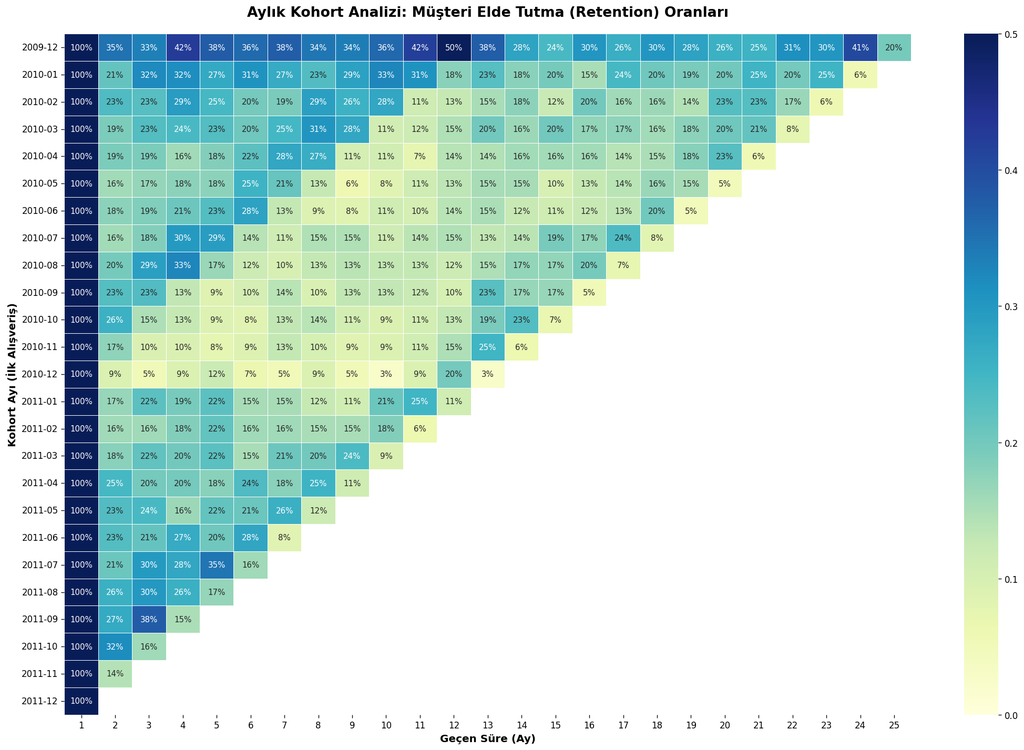

```
---------------------------------------------------------------------------
İŞ BİLGİSİ:
  Retention oranlarının ilerleyen aylarda hızla düşmesi, aktif bir churn
  problemi olduğunu kanıtlıyor ve Faz 3'teki tahmin modelinin önemini vurguluyor.
  Not: 2009-12 kohortu veri toplama penceresinin başındaki 'önceden var olan'
  sadık müşterileri kapsıyor olabilir (left-censoring etkisi).
---------------------------------------------------------------------------
```

```python
# ═══════════════════════════════════════════════════════════════════
# FAZ 1.6: KOHORT ANALİZİ — RETENTION ISI HARİTASI
# ═══════════════════════════════════════════════════════════════════
# Her müşteri grubunun (kohort = ilk alışveriş ayı) ilerleyen aylarda
# platforma dönüş oranını ölçüyoruz. Bu analiz churn probleminin
# büyüklüğünü ve aciliyetini görsel olarak ortaya koyar.

df_cohort = df.copy()
df_cohort['InvoiceMonth'] = df_cohort['InvoiceDate'].dt.to_period('M')
df_cohort['CohortMonth']  = (df_cohort.groupby('Customer ID')['InvoiceDate']
                              .transform('min').dt.to_period('M'))

inv_year  = df_cohort['InvoiceMonth'].dt.year
inv_month = df_cohort['InvoiceMonth'].dt.month
coh_year  = df_cohort['CohortMonth'].dt.year
coh_month = df_cohort['CohortMonth'].dt.month

df_cohort['CohortIndex'] = (inv_year - coh_year) * 12 + (inv_month - coh_month) + 1

cohort_data   = df_cohort.groupby(['CohortMonth', 'CohortIndex'])['Customer ID'].nunique().reset_index()
cohort_counts = cohort_data.pivot(index='CohortMonth', columns='CohortIndex', values='Customer ID')
retention     = cohort_counts.divide(cohort_counts.iloc[:, 0], axis=0)

plt.figure(figsize=(18, 12))
sns.heatmap(retention, annot=True, fmt='.0%', cmap='YlGnBu',
            vmin=0.0, vmax=0.5, linewidths=0.5, annot_kws={"size": 9})
plt.title('Aylık Kohort Analizi: Müşteri Elde Tutma (Retention) Oranları',
          fontsize=16, fontweight='bold', pad=20)
plt.ylabel('Kohort Ayı (İlk Alışveriş)', fontsize=12, fontweight='bold')
plt.xlabel('Geçen Süre (Ay)', fontsize=12, fontweight='bold')
plt.yticks(rotation=0)
plt.tight_layout()
plt.show()

print("-" * 75)
print("İŞ BİLGİSİ:")
print("  Retention oranlarının ilerleyen aylarda hızla düşmesi, aktif bir churn")
print("  problemi olduğunu kanıtlıyor ve Faz 3'teki tahmin modelinin önemini vurguluyor.")
print("  Not: 2009-12 kohortu veri toplama penceresinin başındaki 'önceden var olan'")
print("  sadık müşterileri kapsıyor olabilir (left-censoring etkisi).")
print("-" * 75)
```